# hw12

K Iwasaki

August 2, 2017

# 0. Quick data exploration and data clean up

```r
data = read.table("videos.txt", fill = TRUE, header = TRUE)
head(data)
```

```
##      video_id            uploader  age      category length views rate
## 1 9QR1tni70fo              BHJJYP 1131        Comedy    126   204 3.00
## 2 l1DCSqAJ740          musicalrox 1236         Music    243  1652 3.91
## 3 ZES_o3XYGjM        tessaceleste 1243 Entertainment    105   898 4.48
## 4 4I8b40cViDE booloveswondergirls 1237 Entertainment    278   928 5.00
## 5 Elp6Bf0HJIM  Fizz101Productionz 1252        Comedy     26   392 1.50
## 6 VPuKu7aU9GY         slytherin66 1236 Entertainment    252   318 5.00
##   ratings comments
## 1       2        1
## 2      11        4
## 3      81       36
## 4      24       13
## 5       8       17
## 6       2        3
```

```r
nrow(data)
```

```
## [1] 12677
```

```r
# check number of na in each col
sapply(data, function(x) sum(is.na(x)))
```

```
## video_id uploader      age category   length    views     rate  ratings
##        0        0     3197        0        0        0     3197     3197
## comments
##     3197
```

```r
# transform factor into numeric
data$views = as.numeric(levels(data$views))[data$views]
data$length = as.numeric(levels(data$length))[data$length]
# check number of na in each col again
sapply(data, function(x) sum(is.na(x)))
```

```
## video_id uploader      age category   length    views     rate  ratings
##        0        0     3197        0     6385     6385     3197     3197
## comments
##     3197
```

```r
# remove rows containing NA in the three columns
data = data[complete.cases(data[, c("length", "views", "rate")]),]
nrow(data)
```

```
## [1] 6292
```

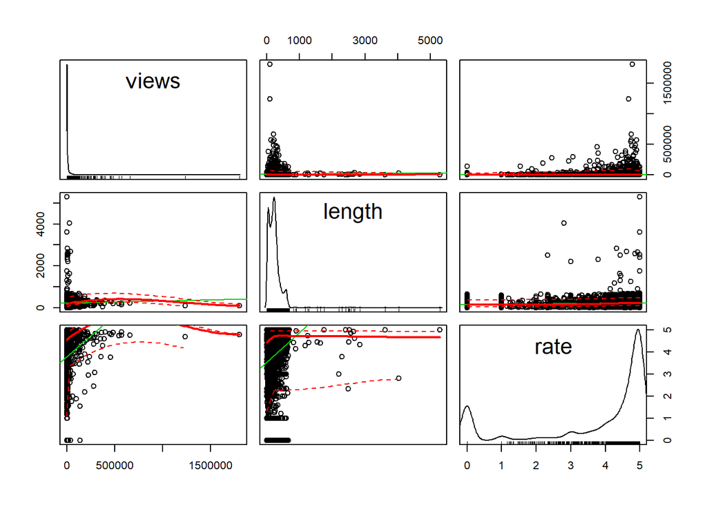

```r
scatterplotMatrix(data[, c("views", "length", "rate")])
```

```r
# examine views column
summary(data$views)
```

```
##    Min. 1st Qu.  Median    Mean 3rd Qu.    Max.
##       3     421    1736   10050    6764 1808000
```

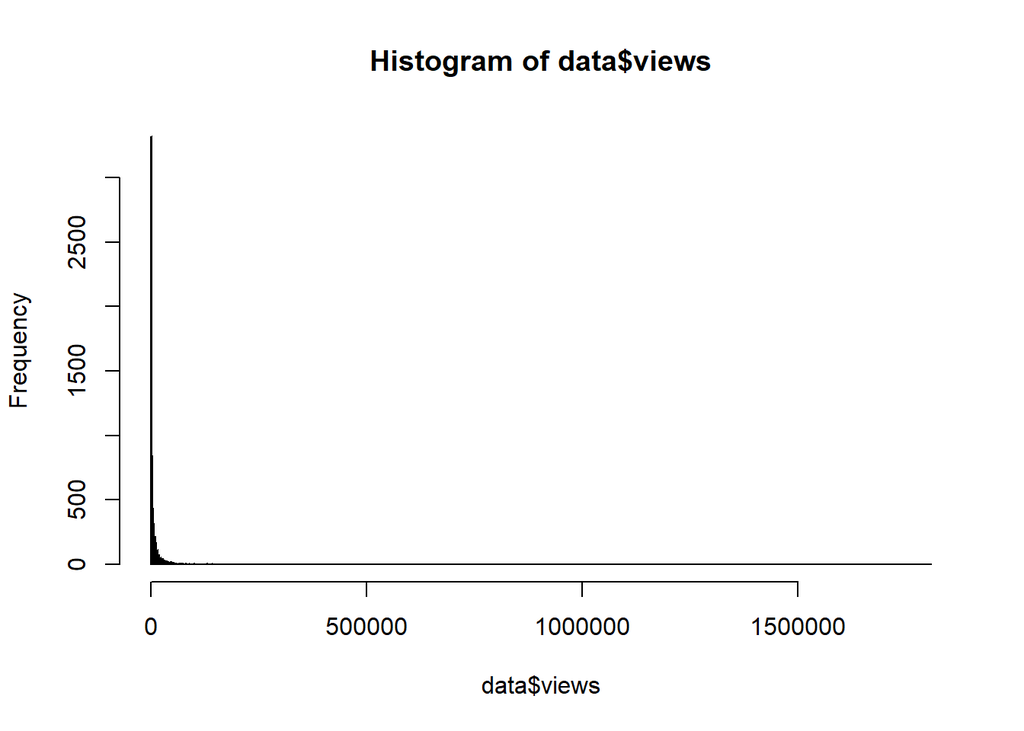

```r
hist(data$views, breaks = 1000)
```

```r
# extremely skewed to the right

# check outliers
data[data$views > 500000, ]
```

```
##          video_id          uploader  age category length   views rate
## 6785  -2kpyJcyzEE        amerikalim  544   Comedy    103 1237488 4.68
## 6799  q2lo5aQeDgw          hakan222  779   Comedy     98 1807640 4.79
## 9582  QVc29bYIvCM        robbanzana  836    Music    219  570833 4.91
## 10051 S8ENPA6F1Hg BritneyVideoVault 1145    Music    208  661115 4.75
## 10818 Q3X-7W4_EQM     kawaimasanori 1220   Comedy    132  572812 4.75
## 11038 fUDWcTSNRkE         SteveAATW 1126    Music    194  543672 4.73
##       ratings comments
## 6785      328      316
## 6799     3801     1943
## 9582     1501     1008
## 10051    1316      533
## 10818     122       15
## 11038     456      292
```

```r
# examine length column
summary(data$length)
```

```
##    Min. 1st Qu.  Median    Mean 3rd Qu.    Max.
##       1      96     199     220     287    5289
```

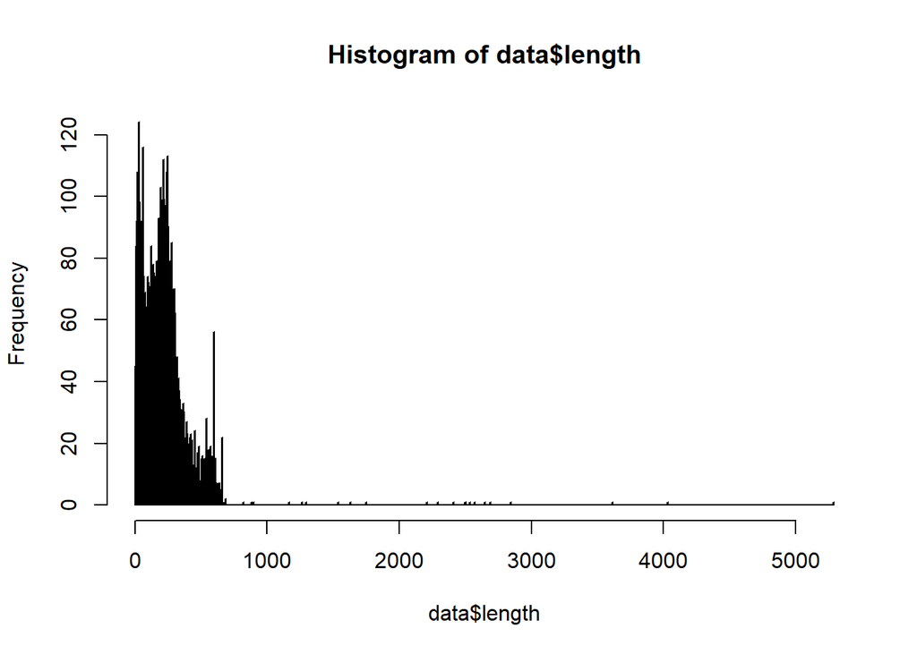

```r
hist(data$length, breaks = 1000)
```

```r
# extremely skewed to the right

# check outliers
data[data$length > 1000, ]
```

```
##          video_id     uploader  age      category length views rate
## 4178  sZYueEqL2-A      tokyomx  997 Entertainment   2648 11431 4.93
## 4181  DsSj3N4lqRw      tokyomx 1030 Entertainment   2531  6944 5.00
## 4184  FUrzoe329zU      tokyomx  880 Entertainment   1634 31813 4.41
## 4185  mqH5RFWYj3M      tokyomx  965 Entertainment   2502 10734 4.44
## 4186  H2K9JDjh-vA      tokyomx 1039 Entertainment   2842  8769 4.33
## 4187  _Dyz5w8PKms      tokyomx 1004 Entertainment   2411  5393 5.00
## 4188  h6NnjIlqCOo      tokyomx  971 Entertainment   2574  7875 4.86
## 4226  cYbNBHfha3o     malhacao 1232 Entertainment   1169 14229 4.27
## 4743  dzmm0DkJtac     TraitorX  598        Sports   1291  1120 4.43
## 5757  nfolzfsJfwE uctelevision 1065     Education   1746   278 5.00
## 5785  eQc8F7pYjcY uctelevision 1065     Education   5289  1071 5.00
## 6798  Ku6lfMYdwrs       IPWfed  573 Entertainment   1538 14345 4.45
## 12266 iPzhzHCy8fk  rosaryfilms 1232     Education   3613   714 5.00
## 12436 V3Gk7i4VYg4  jacoblee776  324        Comedy   1261 26156 4.74
```

[output cut: 25 more lines]

```r
# examine rate
summary(data$rate)
```

```
##    Min. 1st Qu.  Median    Mean 3rd Qu.    Max.
##   0.000   3.608   4.700   3.829   5.000   5.000
```

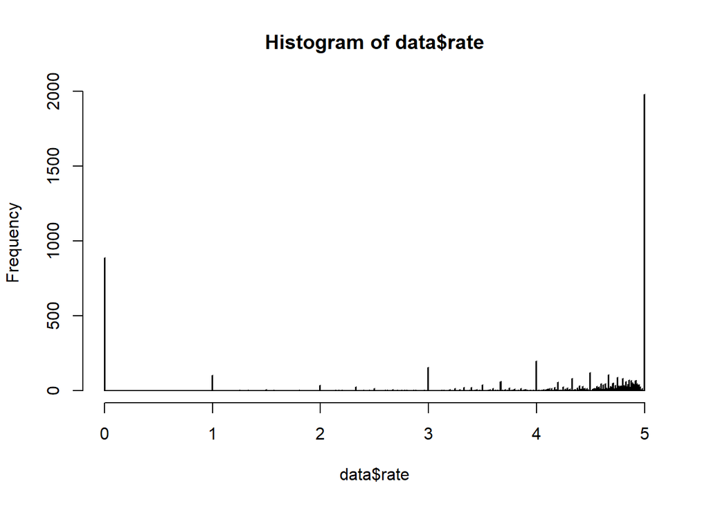

```r
hist(data$rate, breaks = 1000)
```

# 1. Fit a linear model predicting the number of views (views), from the length of a video (length) and its average user rating (rate).

```r
(model1 = lm(views ~ length + rate, data = data))
```

```
##
## Call:
## lm(formula = views ~ length + rate, data = data)
##
## Coefficients:
## (Intercept)       length         rate
##    1383.874        1.926     2152.401
```

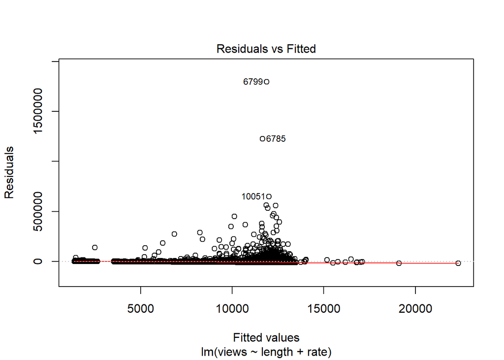

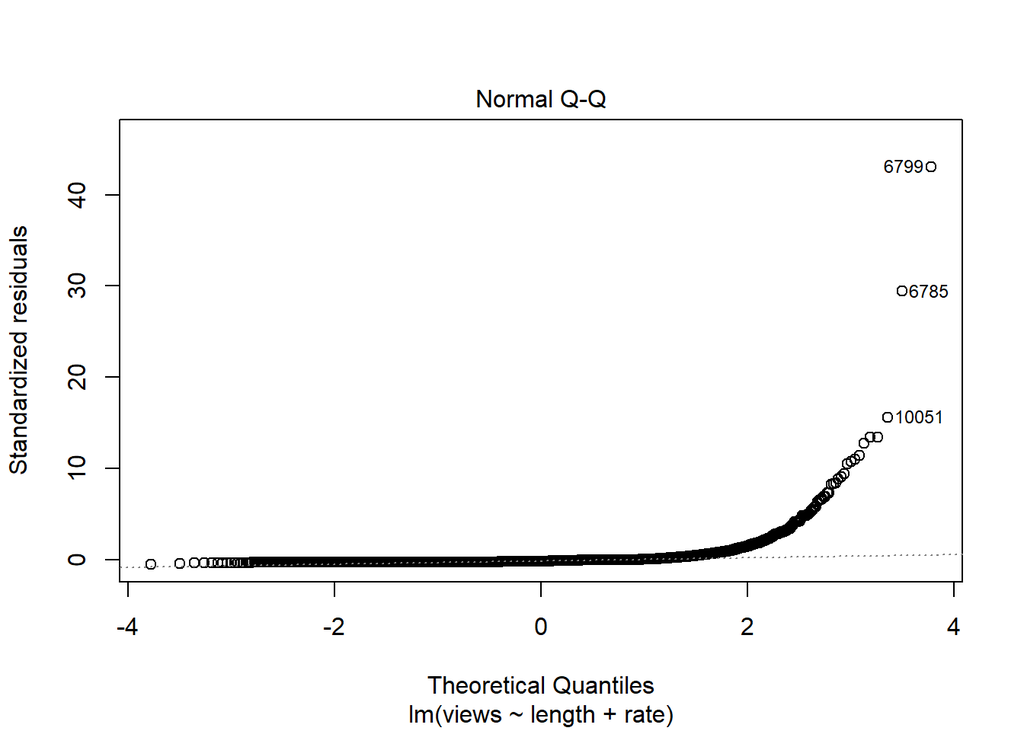

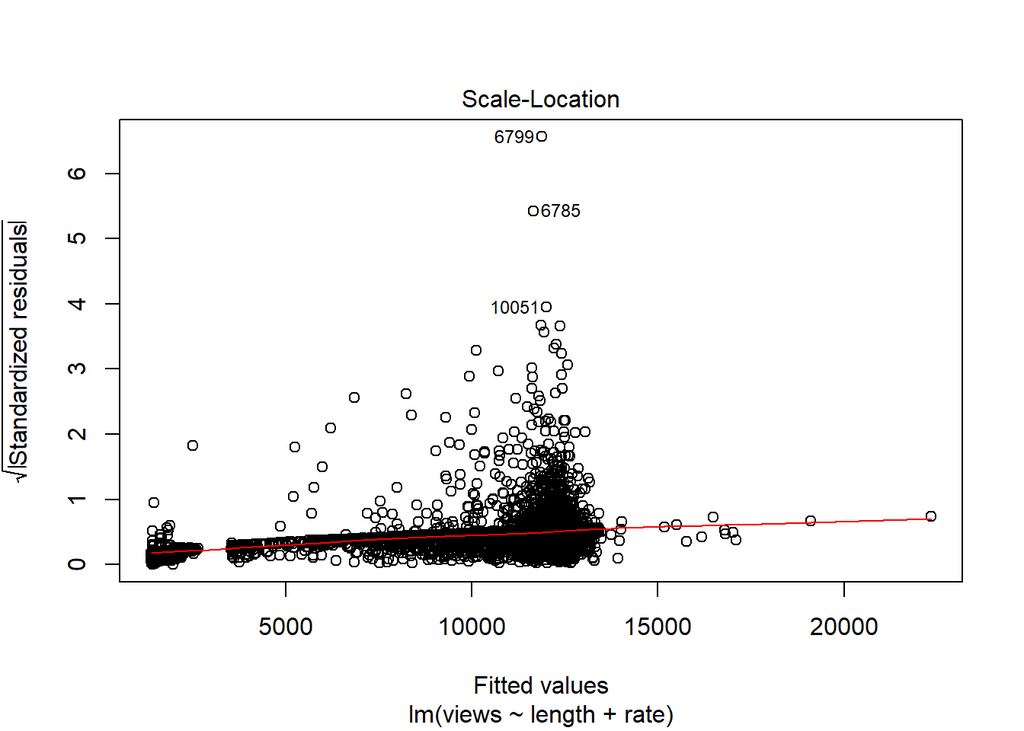

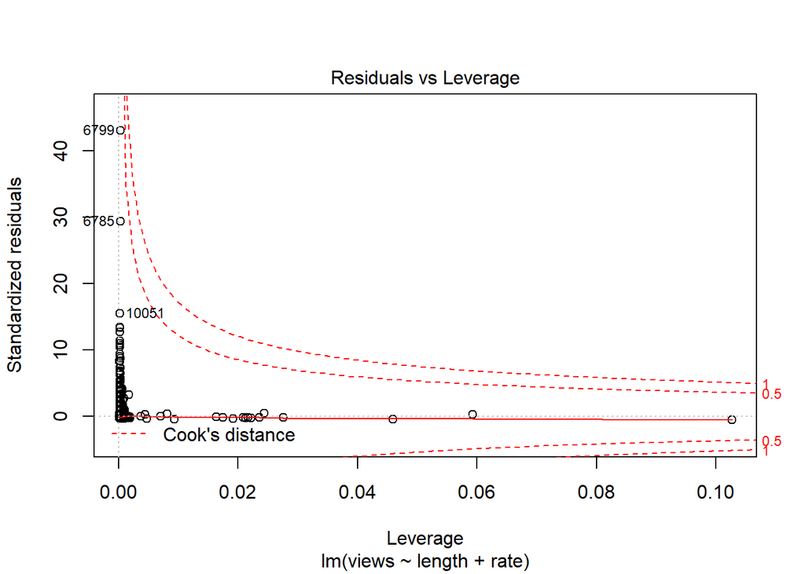

```r
plot(model1)
```

# 2. Using diagnostic plots, background knowledge, and statistical tests, assess all 6 assumptions of the CLM. When an assumption is violated, state what response you will take.

1. Linear population model. This assumption is ok.
2. Random sampling. There is not much information about how this data is collected.I assume this assumption isn’t violated.
3. No perfect multicolliearity. The plot below doesn’t show perfect multicolliearity.

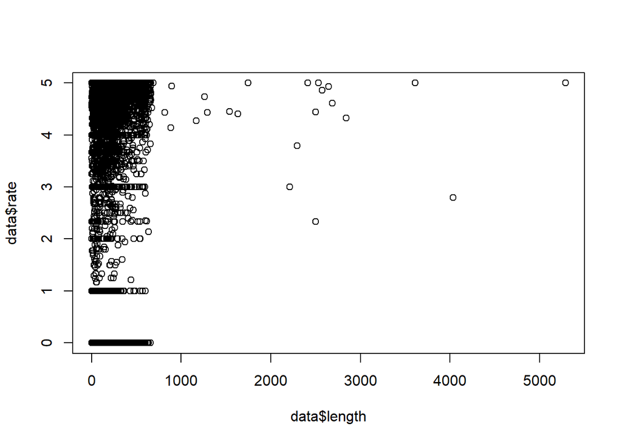

```r
plot(data$length, data$rate)
```

4. Zero-conditional mean. Look at the Residuals vs. Fitted plot. Smooth line in the chart is around 0. It seems this assumption is not violated.

5. Homoskedasticity. Look at the Residuals vs. Fitted plot and Scale-location plot. A bit difficult to say if the model shows homoskedasticity or not. To double-check, run a Breaush-Pagan test. p-value is large so we don’t reject the null hypothesis that the model has homoskedasticity. Thus this assumption is not violated.

```r
bptest(model1)
```

```
##
##  studentized Breusch-Pagan test
##
## data:  model1
## BP = 2.6778, df = 2, p-value = 0.2621
```

6. Normality of error term. Look at the q-q plot. This assumption is violated. Since the sample size is 6292, we assume normality of our sampling distributions from the large sample size. Thus, no action on this violation.

# 3. Generate a printout of your model coefficients, complete with standard errors that are valid given your diagnostics. Comment on both the practical and statistical significance of your coefficients.

Use robust standard errors since it’s good practice and I wasn’t sure about homoskedasticity.

```r
coeftest(model1, vcov = vcovHC)
```

```
##
## t test of coefficients:
##
##              Estimate Std. Error t value  Pr(>|t|)
## (Intercept) 1383.8740   387.1406  3.5746 0.0003534 ***
## length         1.9259     1.7300  1.1132 0.2656619
## rate        2152.4013   178.5943 12.0519 < 2.2e-16 ***
## ---
## Signif. codes:  0 '***' 0.001 '**' 0.01 '*' 0.05 '.' 0.1 ' ' 1
```

Look at the predictor variables.

## rate

p-value is quite small and thus statistically significant. coefficient is 2152. What this means is that holding length is fixed, another 1 point on rate are associated with 2152 views. This is pratically significant.

## length

p-value is quite large as 0.265 and thus this predictor variable is not statistically significant. Coefficient is only 1.9 and not pratically significant.